[figure not shown]

# Packages for Data Analysis

[Ahmed Moustafa](https://github.com/ahmedmoustafa)

# Packages for Data Analysis

We will be discussing three important Python libraries that are commonly used for data analysis: **pandas**, **matplotlib**, and **numpy**.

# Importing Libraries in Python

- In Python, libraries or packages are collections of **pre-written** code that can be imported and used in your own programs.
- The most common way to import a library is using the `import` statement followed by the name of the library.
- For example, to import the `math` library, you would use the following statement:

```python
import math

math.sqrt(25)
```

```
5.0
```

# Importing Libraries with Aliases

- You can also import a library with an alias using the `as` keyword.
- This can be useful when you want to use a shorter name for a library in your code.
- For example, to import the `math` library with the alias `m`, you would use the following statement:

```python
import math as m

m.sqrt(25)
```

```
5.0
```

# Installing a library

- If a package is not already installed, you can install within your notebook using:

```
%pip install library_name
```

- Example to install Pandas:

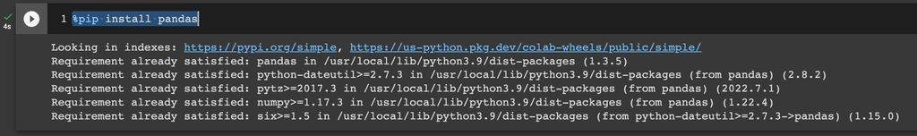

# Pandas

- Pandas is a Python library that is used for data manipulation and analysis.
- It provides data structures for efficiently storing and manipulating large datasets.
- Let's start with an example of how to use Pandas to load a CSV file.

# Titanic Dataset

[output not shown]

# Loading a CSV file with Pandas

```python
import pandas as pd

url = 'https://web.stanford.edu/class/archive/cs/cs109/cs109.1166/stuff/titanic.csv'
titanic = pd.read_csv(url) # Load Titanic dataset

titanic.shape # The dimension of the dataframe (the table)
```

```
(887, 8)
```

# Viewing Data

- Once you've loaded data into a `DataFrame`, you can start exploring it using various Pandas functions.
- The `head()` and `tail` functions are useful functions for quickly viewing the first and last few rows of a `DataFrame`.

```python
titanic.head() # Print the first few rows of the DataFrame
```

|  | Survived | Pclass | Name | Sex | Age | Siblings/Spouses Aboard | Parents/Children Aboard | Fare |
| --- | --- | --- | --- | --- | --- | --- | --- | --- |
| 0 | 0 | 3 | Mr. Owen Harris Braund | male | 22.0 | 1 | 0 | 7.2500 |
| 1 | 1 | 1 | Mrs. John Bradley (Florence Briggs Thayer) Cum... | female | 38.0 | 1 | 0 | 71.2833 |
| 2 | 1 | 3 | Miss. Laina Heikkinen | female | 26.0 | 0 | 0 | 7.9250 |
| 3 | 1 | 1 | Mrs. Jacques Heath (Lily May Peel) Futrelle | female | 35.0 | 1 | 0 | 53.1000 |
| 4 | 0 | 3 | Mr. William Henry Allen | male | 35.0 | 0 | 0 | 8.0500 |

```python
titanic.tail() # Print the last few rows of the DataFrame
```

|  | Survived | Pclass | Name | Sex | Age | Siblings/Spouses Aboard | Parents/Children Aboard | Fare |
| --- | --- | --- | --- | --- | --- | --- | --- | --- |
| 882 | 0 | 2 | Rev. Juozas Montvila | male | 27.0 | 0 | 0 | 13.00 |
| 883 | 1 | 1 | Miss. Margaret Edith Graham | female | 19.0 | 0 | 0 | 30.00 |
| 884 | 0 | 3 | Miss. Catherine Helen Johnston | female | 7.0 | 1 | 2 | 23.45 |
| 885 | 1 | 1 | Mr. Karl Howell Behr | male | 26.0 | 0 | 0 | 30.00 |
| 886 | 0 | 3 | Mr. Patrick Dooley | male | 32.0 | 0 | 0 | 7.75 |

# Basic Statistics

- You can use Pandas to calculate basic statistics on your data, such as mean, median, and standard deviation.
- The `describe()` function provides a summary of the basic statistics of each column in the DataFrame.

```python
titanic.describe()
```

|  | Survived | Pclass | Age | Siblings/Spouses Aboard | Parents/Children Aboard | Fare |
| --- | --- | --- | --- | --- | --- | --- |
| count | 887.000000 | 887.000000 | 887.000000 | 887.000000 | 887.000000 | 887.00000 |
| mean | 0.385569 | 2.305524 | 29.471443 | 0.525366 | 0.383315 | 32.30542 |
| std | 0.487004 | 0.836662 | 14.121908 | 1.104669 | 0.807466 | 49.78204 |
| min | 0.000000 | 1.000000 | 0.420000 | 0.000000 | 0.000000 | 0.00000 |
| 25% | 0.000000 | 2.000000 | 20.250000 | 0.000000 | 0.000000 | 7.92500 |
| 50% | 0.000000 | 3.000000 | 28.000000 | 0.000000 | 0.000000 | 14.45420 |
| 75% | 1.000000 | 3.000000 | 38.000000 | 1.000000 | 0.000000 | 31.13750 |
| max | 1.000000 | 3.000000 | 80.000000 | 8.000000 | 6.000000 | 512.32920 |

# Indexing and Selection

- You can use indexing and selection to retrieve specific data from a `DataFrame`.
- The `loc[]` function is used for label-based indexing, where you can specify the row and column labels.
- The `iloc[]` function is used for integer-based indexing, where you can specify the row and column numbers.

```python
titanic.iloc[2:5]
```

|  | Survived | Pclass | Name | Sex | Age | Siblings/Spouses Aboard | Parents/Children Aboard | Fare |
| --- | --- | --- | --- | --- | --- | --- | --- | --- |
| 2 | 1 | 3 | Miss. Laina Heikkinen | female | 26.0 | 0 | 0 | 7.925 |
| 3 | 1 | 1 | Mrs. Jacques Heath (Lily May Peel) Futrelle | female | 35.0 | 1 | 0 | 53.100 |
| 4 | 0 | 3 | Mr. William Henry Allen | male | 35.0 | 0 | 0 | 8.050 |

```python
titanic.loc[2:5, ['Survived', 'Pclass']]
```

|  | Survived | Pclass |
| --- | --- | --- |
| 2 | 1 | 3 |
| 3 | 1 | 1 |
| 4 | 0 | 3 |
| 5 | 0 | 3 |

# Filtering Data

- You can use Boolean indexing to filter data in a DataFrame based on a certain condition.
- For example, you can filter the Titanic dataset to only show passengers who survived:

```python
# Filter Titanic dataset to only show passengers who survived
survivors = titanic[titanic['Survived'] == 1]
survivors.head()
```

|  | Survived | Pclass | Name | Sex | Age | Siblings/Spouses Aboard | Parents/Children Aboard | Fare |
| --- | --- | --- | --- | --- | --- | --- | --- | --- |
| 1 | 1 | 1 | Mrs. John Bradley (Florence Briggs Thayer) Cum... | female | 38.0 | 1 | 0 | 71.2833 |
| 2 | 1 | 3 | Miss. Laina Heikkinen | female | 26.0 | 0 | 0 | 7.9250 |
| 3 | 1 | 1 | Mrs. Jacques Heath (Lily May Peel) Futrelle | female | 35.0 | 1 | 0 | 53.1000 |
| 8 | 1 | 3 | Mrs. Oscar W (Elisabeth Vilhelmina Berg) Johnson | female | 27.0 | 0 | 2 | 11.1333 |
| 9 | 1 | 2 | Mrs. Nicholas (Adele Achem) Nasser | female | 14.0 | 1 | 0 | 30.0708 |

# Grouping and Aggregation

- Grouping and aggregation are powerful tools for summarizing and analyzing data in a DataFrame.
- You can group data in a DataFrame based on one or more columns, and then apply an aggregation function like `sum()`, `mean()`, or `count()`.
- For example, you can group the Titanic dataset by ticket class and calculate the average age for each class:

```python
# Group Titanic dataset by ticket class and calculate the average age for each class
age_by_class = titanic.groupby('Pclass')['Age'].mean()
age_by_class
```

```
Pclass
1    38.788981
2    29.868641
3    25.188747
Name: Age, dtype: float64
```

# Matplotlib

- Matplotlib is a Python library used for creating data visualizations.
- It provides a wide range of tools for creating line plots, bar plots, histograms, scatterplots

# Plotting a Simple Line Graph with Matplotlib

```python
import pandas as pd

url = 'https://raw.githubusercontent.com/datasets/co2-fossil-global/master/global.csv'
co2 = pd.read_csv(url)

co2.head()
```

|  | Year | Total | Gas Fuel | Liquid Fuel | Solid Fuel | Cement | Gas Flaring | Per Capita |
| --- | --- | --- | --- | --- | --- | --- | --- | --- |
| 0 | 1751 | 3 | 0 | 0 | 3 | 0 | 0 | NaN |
| 1 | 1752 | 3 | 0 | 0 | 3 | 0 | 0 | NaN |
| 2 | 1753 | 3 | 0 | 0 | 3 | 0 | 0 | NaN |
| 3 | 1754 | 3 | 0 | 0 | 3 | 0 | 0 | NaN |
| 4 | 1755 | 3 | 0 | 0 | 3 | 0 | 0 | NaN |

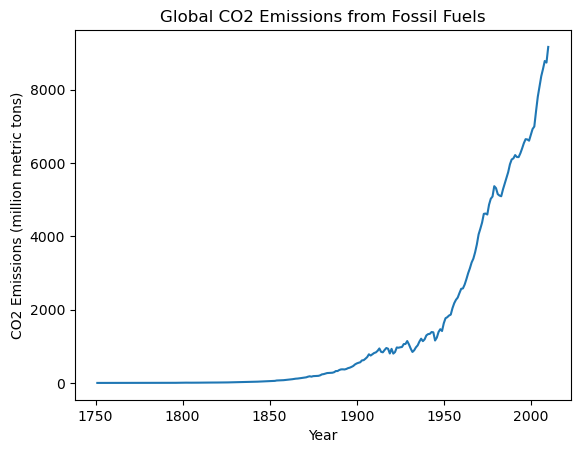

```python
import matplotlib.pyplot as plt

plt.plot(co2['Year'], co2['Total'])
plt.xlabel('Year')
plt.ylabel('CO2 Emissions (million metric tons)')
plt.title('Global CO2 Emissions from Fossil Fuels')
plt.show()
```

# Creating a Bar Plot with Matplotlib

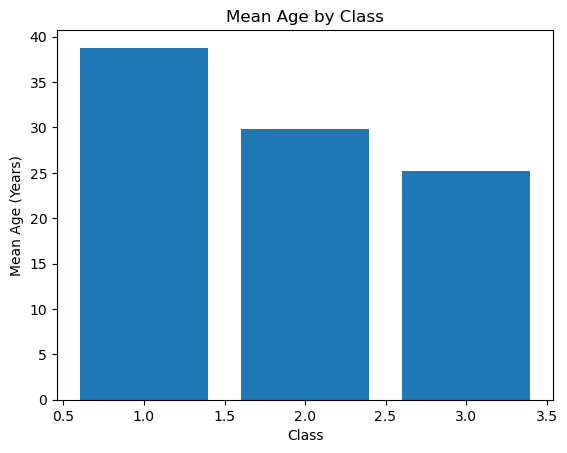

```python
plt.bar(age_by_class.index, age_by_class.values)

plt.title('Mean Age by Class')
plt.xlabel('Class')
plt.ylabel('Mean Age (Years)')

plt.show()
```

# Numpy

- NumPy is a Python library used for numerical computing.
- It provides a wide range of tools for working with arrays and matrices.
- NumPy is used in many scientific computing applications.
- Let's start with an example of how to use NumPy to create an array.

# Creating a NumPy Array

- To create a NumPy array, you can use the `numpy.array()` function.
- Here's the code to create a NumPy array:

```python
import numpy as np

data = [1, 2, 3, 4, 5]
arr = np.array(data)
arr
```

```
array([1, 2, 3, 4, 5])
```

# NumPy Array Operations

- You can perform various operations on NumPy arrays.
- For example, you can add, subtract, multiply, and divide arrays.
- Here's the code to add two arrays:

```python
import numpy as np

arr1 = np.array([1, 2, 3])
arr2 = np.array([4, 5, 6])
arr3 = arr1 + arr2
arr3
```

```
array([5, 7, 9])
```

# NumPy Array Indexing and Slicing

- You can also index and slice NumPy arrays.
- Here's the code to create a NumPy array and slice it:

```python
import numpy as np

arr = np.array([1, 2, 3, 4, 5])
arr[2]
```

```
3
```

```python
arr[1:4]
```

```
array([2, 3, 4])
```

# NumPy Broadcasting

- Broadcasting is a powerful NumPy feature that allows you to perform operations on arrays of different shapes.
- Here's an example:

```python
import numpy as np

# Create a 2D array of shape (3, 4)
arr1 = np.array([[1, 2, 3, 4],
                 [5, 6, 7, 8],
                 [9, 10, 11, 12]])

# Create a 1D array of shape (4,)
arr2 = np.array([2, 2, 2, 2])

# Add the 1D array to each row of the 2D array using broadcasting
result = arr1 + arr2

print(result)
```

```
[[ 3  4  5  6]
 [ 7  8  9 10]
 [11 12 13 14]]
```

# NumPy Broadcasting 2/3

In this example, we have a 2D NumPy array arr1 with shape (3, 4) and a 1D NumPy array arr2 with shape (4,). We want to add the values in arr2 to each row of arr1. Normally, this operation would not be possible because the two arrays have different shapes. However, NumPy broadcasting allows us to perform this operation by "stretching" or "broadcasting" the 1D array to match the shape of the 2D array.

In this case, NumPy broadcasts the 1D array arr2 to a 2D array of shape (3, 4) by duplicating its values along the first dimension. This allows us to perform element-wise addition between the two arrays.

# NumPy Broadcasting 3/3

Note that broadcasting is not always possible or desirable, and certain conditions must be met for it to work correctly. For example, the trailing dimensions of the two arrays must either match or be equal to 1, among other rules. It's important to understand these rules and use broadcasting judiciously to avoid errors and unexpected results.

# Seaborn

- Seaborn is a Python data visualization library based on Matplotlib.
- It provides a high-level interface for creating informative and attractive statistical graphics.
- Seaborn works well with pandas dataframes and provides tools for visualizing relationships between variables.

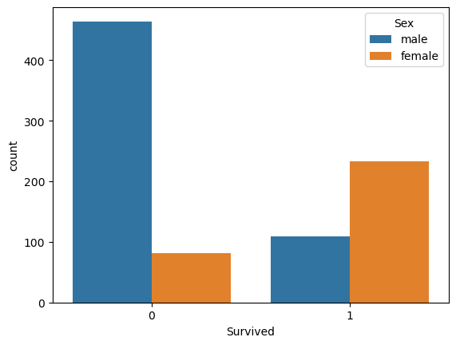

```python
import seaborn as sns
sns.countplot (data = titanic, x = 'Survived', hue = 'Sex')
```